# Geospatial Code Replication Workflow

Jyotishka Datta

6/22/2019

# Goals

To create a supervised learning framework for the child maltreatment data in Little Rock between 2015 and 2018. The framework I am trying to follow is similar to the one here: (Predicting Spatial Risk of Opioid Overdoses in Providence, RI)[https://pennmusa.github.io/MUSA_801.io/project_5/].

The first task is to perform an exploratory analysis similar to the one here (exploratory analysis for opioid overdose)[https://pennmusa.github.io/MUSA_801.io/project_5/#2_exploratory_analysis].

# Package Dependencies and Preamble

```r
# install.packages("devtools")
# devtools::install_github("thomasp85/patchwork")

library("sf")            # Spatial data objects and methods
library("mapview")       # Interactive Map Viewing
library("ggmap")         # ggplot2 addon for base maps
library("cowplot")
library("spatstat")      # KDE and other spatial functions
library("raster")        # cell-based spatial operations
library("tidyverse")     # data manipulation framework
library("Hmisc")         # using cut2() functions for ggplot legends
library("fitdistrplus")  # Distribution fitting functions
library("lubridate")     # Power tools for handling dates
library("tidycensus")
library("lwgeom")
library("Hmisc")
library("hrbrthemes")
library("gridExtra")
library("patchwork")
library("spdep")         # KNN functions
library("foreach")
library("doParallel")
library("corrplot")
library("ranger")        # randomforest implimentation
library("glmnet")        # for Ridge and Lasso Regression
library("knitr")         # for kable table
library("kableExtra")
library("FNN")           # KNN for CPS vs. NN plots
library("groupdata2")
library("htmltools")
library("viridis")
library("viridisLite")

# Load new packages (might be redundant)
pacman::p_load(rgdal, broom, rgeos, GISTools)

# Load old packages
pacman::p_load(dplyr, ggplot2, ggthemes, magrittr)
```

# Report Appendix 1: Data wrangling

Step 1. Detect all xls/xlsx and csv files in a directory and read them into a list.

The following chunk imports the built environment factors and the child maltreatment data. The inputs are `.xls`, `.xlsx`, and `.csv` files in a folder. The output is a list data type where each element of the list if one of the input data sets in the `sf` spatial data format.

## Reading Variables

```r
# requires all data in *.csv or *.xls files containing coordinate field names "X" and "Y"
# `crs` in the call to `st_as_sf()` needs to be set to the ESPG code of your data projection
# `base_dir` file path and many feature names are specified for the current project.

##1.1 Global Variables
# mapviewOptions(basemaps = c("Stamen.TonerLite", "OpenStreetMap.DE"))
base_dir = "C:/Users/jd033/Box/Child Maltreatment"


##2.1 Load Data
files <-list.files(file.path(base_dir,"/Little Rock Data/CSV"), pattern = "*\\.xlsx$|*\\.csv$")
var_list <- vector(mode = "list")
var_names <- NULL
for(i in seq_along(files)){
  filename <- str_sub(files[i], start = 1, end = -5)
  sf_i <- tryCatch({
    if(tools::file_ext(files[i]) == "xlsx"){
      dat <- readxl::read_xlsx(file.path(base_dir,"/Little Rock Data/CSV",files[i]))
    } else if(tools::file_ext(files[i]) == "csv"){
      dat <- read.csv(file.path(base_dir,"/Little Rock Data/CSV",files[i]))
    }
    dat %>%
      filter(!is.na(X) | !is.na(Y)) %>%
      st_as_sf(., coords = c("X", "Y"), crs = 2765)
  }, error = function(e){
    cat(filename, "error = ",e$message,"\n")
    return(e)
  }
  )
  if(!inherits(sf_i, "error")){
    var_list[[length(var_list)+1]] <- sf_i
    var_names[length(var_list)] <- filename
  }
}
names(var_list) <- var_names
knitr::kable(var_names, caption = "List of Variables")
```

List of Variables

| x |
| --- |
| Banks. |
| BarberAndBeautyShops. |
| CM_geocoded |
| HighSchoolsPublic. |
| HotelMotel. |
| LiquorStores. |
| MajorDeptRetailDiscount. |
| Rental_MobileHomes. |
| Rental_SingleToQuad. |
| TattooPiercing. |

## Read LR shapefile

The following code chunk reads the shapefile `LR_Tracts_Working51.shp` from the project folder and plots the variable `ALAND`.

**Note that this is different from what was done in PAP-VA, where the neighbourhoods shapefile was imported from their data portal (using `read_sf("https://data.richmondgov.com/resource/7juf-nwis.geojson")`).**

The `class`, `dim` and `names` are used to understand what is inside this data frame.

```r
setwd("C:/Users/jd033/Box/Child Maltreatment/Little Rock Data")

nbr = st_read("C:/Users/jd033/Box/Child Maltreatment/Working Files_AR ACS Data/ACS_Tract_Shapefile/LR_Tracts_Working51.shp")
# Class
class(nbr)
```

```
## [1] "sf"         "data.frame"
```

```r
# Dimensions
dim(nbr)
```

```
## [1] 51 17
```

```r
# Info in shapefile
names(nbr)
```

```
##  [1] "STATEFP"    "COUNTYFP"   "TRACTCE"    "GEOID"      "NAME"
##  [6] "NAMELSAD"   "MTFCC"      "FUNCSTAT"   "ALAND"      "AWATER"
## [11] "INTPTLAT"   "INTPTLON"   "Shape_Leng" "Shape_Area" "GEOID_Data"
## [16] "Area"       "geometry"
```

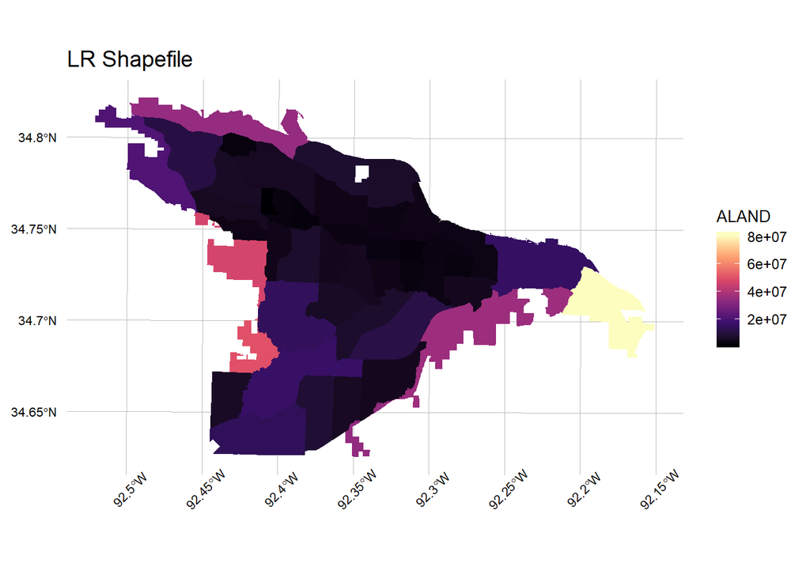

```r
nbr %>%
  ggplot(aes(fill = ALAND)) +
  geom_sf(color = NA) +
  coord_sf(crs = 2765) +
  scale_fill_viridis_c(option = "magma") +
  labs(title = "LR Shapefile") + plotTheme()+
  theme(axis.text.x = element_text(size = 8, angle =45 ), axis.text.y = element_text(size = 8))
```

## Creating raster

This chunk creates a raster object from the spatial data frame `nbr_diss`.

```r
nbr_diss <- nbr %>%
  mutate(dissolve = 1) %>%
  # get rid of slivers
  st_buffer(., dist = 0.1) %>%
  group_by(dissolve) %>%
  summarise()

nbr_rast_SP <- raster(as(nbr_diss, "Spatial"), nrows = 2000, ncol = 2000)
```

This chunk creates a `value` column for each incident of child maltreatment for dissolving.

```r
### get CM_geocoded values (add 1 column for dissolving)
cps_dissolve <- var_list[["CM_geocoded"]] %>%
  mutate(value = 1) %>%
  dplyr::select(value)
```

## Creating Base map

This chunk creates the base map from the bounding box extracted from the `CM_geocoded` file (child maltreatment incidences), and pulls the map using the `ggmap` package.

**Note** One need the Google API to be able to pull the map, which is not shown here. Also, PAP-VA used `get_map` function, which is a little different from the `get_googlemap` function here. It seems `get_map` does not work with this data.

```r
# register_google(key = "<YOUR KEY HERE>")

(cm_bbox = unname(st_bbox(ll(st_buffer(var_list[["CM_geocoded"]],dist = 0.1)))))
```

```
## [1] 1157004.4  106698.8 1256732.6  175921.1
```

```r
cps_base_map   <- get_googlemap(location = cm_bbox,
                          source = "google",
                          maptype = "terrain")
```

## Create fishnet and aggregate child maltreatment by fishnet grids

This chunk will create a fishnet of size 1000 from the `nbr` shapefile that was read earlier, and aggregate child maltreatment by the grid-cells (`net_agg`). Next, the function `st_intersects()` returns the indices for intersecting cells and the `net_agg` data frame. The functions `st_join()` performs spatial left or inner join and `nb2listw()` attaches spatial weights to an `nb` list.

**Note that the `st_crs` step here is a ‘hackish’ way of coercing the two objects to have the same CRS, and it does not reproject the data, but it should not be necessary unless there coordinate reference systems don’t match. One way of checking this is to perform `cps_dissolve %>% st_crs() == nbr %>% st_crs()`.**

```r
st_crs(nbr) <- "+proj=lcc +lat_1=34.76666666666667 +lat_2=33.3 +lat_0=32.66666666666666 +lon_0=-92 +x_0=400000 +y_0=400000
+ellps=GRS80 +towgs84=0,0,0,0,0,0,0 +units=m +no_defs"

net <- st_make_grid(nbr, cellsize = fishnet_grid_dim)

## Check if the CRS's match
cps_dissolve %>% st_crs() == nbr %>% st_crs()
```

```
## [1] TRUE
```

```r
# count CPS incidents per net cell - really just to get net raster into sf polygon format
net_agg <- aggregate(cps_dissolve, net, sum) %>%
  tibble::rowid_to_column(.,"net_id")

# list of net cells IDs that intersect with Little Rock
net_intersect <- st_intersects(nbr, net_agg)

# extract Little Rock net cells based on intersect ID
net_littlerock <- net_agg[unique(unlist(net_intersect)),]
net_hood <- st_join(net_littlerock, nbr, largest = TRUE)
listw <- nb2listw(poly2nb(as(net_littlerock, "Spatial"), queen = TRUE))
```

## Reading Census decennial data using `tidycensus`

This chunk uses the **tidycensus** package: namely, the `get_decennial` function, which lets one pull data from 1990, 2000, and 2010 decennial US Census APIs, and `get_acs`, for the 5-year American Community Survey APIs.

Now, for the current project, we will use ACS data extracted and re-coded separately, depending on which features are more important in this context. **I am still running these lines as the remainder of this code critically depends on the data-sets created at this step. It should be possible to “replace” these decennial or ACS data-sets at a later stage.**

There is also some concern about Census Bureau changing the definition of variables and changing variable IDS and accessing permits in near future.

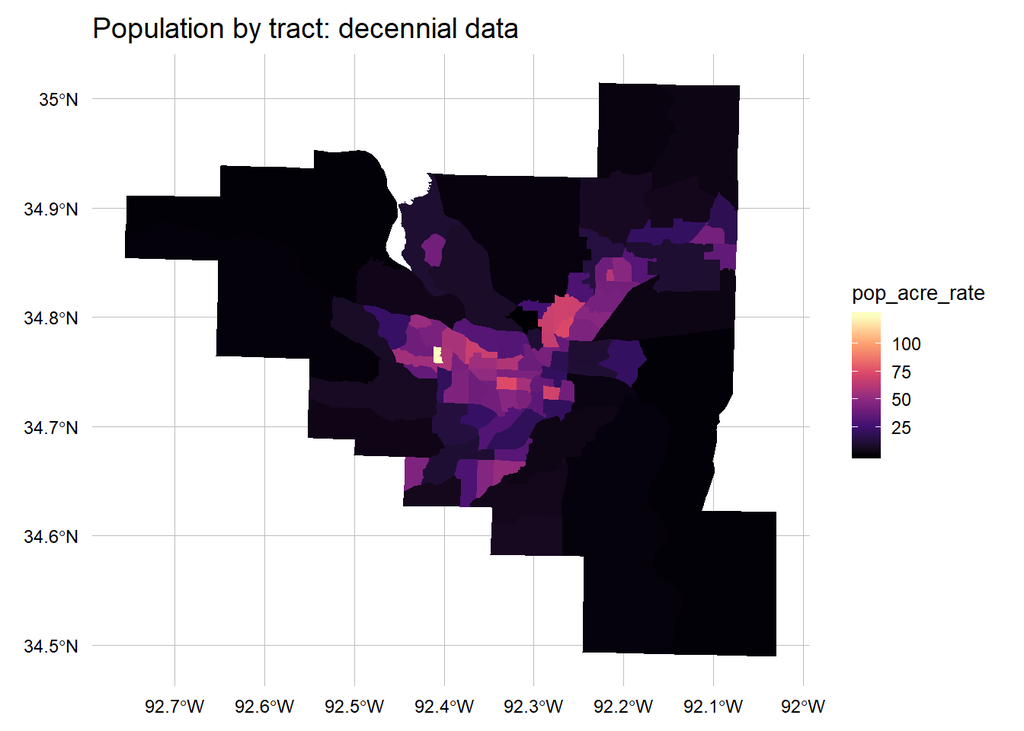

```r
vars10 <- c("P001001") # total population (correct, I checked the web)
## get total 2010 census pop for blocks & calculate area
littlerock_tract <- get_decennial(geography = "tract", variables = vars10, year = 2010,
summary_var = "P001001", state = "05", county = "119", geometry = TRUE)
# calc area

littlerock_tract <- littlerock_tract %>%
  mutate(acre = as.numeric(st_area(littlerock_tract)*2.29568e-5),
         # acre = units::set_units(acre, acre),
         pop_acre_rate = value / acre)

littlerock_tract %>%
  ggplot(aes(fill = pop_acre_rate)) +
  geom_sf(color = NA) +
  # coord_sf(crs = 2765) +
  scale_fill_viridis_c(option = "magma") +
  labs(title = "Population by tract: decennial data")+
  plotTheme()
```

## Issues with Intersection

The next few chunks of R code will calculate child maltreatment counts and rates and plot as a map to show the locations. This chunk is running into issues as the two data-sets that we are trying to intersect are being projected into non-overlapping spaces, probably because of some issues with the files being imported.

**Note: Once again, the setting the “prjstring” using `st_crs()` is not a good idea, and it does not work here.**

```r
st_crs(littlerock_tract) <- "+proj=lcc +lat_1=34.76666666666667 +lat_2=33.3 +lat_0=32.66666666666666 +lon_0=-92 +x_0=400000 +y_0=400000
+ellps=GRS80 +towgs84=0,0,0,0,0,0,0 +units=m +no_defs"

(net_blocks_intersect <- st_intersection(littlerock_tract, net_littlerock))
```

```
## Simple feature collection with 0 features and 9 fields
## bbox:           xmin: NA ymin: NA xmax: NA ymax: NA
## epsg (SRID):    NA
## proj4string:    +proj=lcc +lat_1=34.76666666666667 +lat_2=33.3 +lat_0=32.66666666666666 +lon_0=-92 +x_0=400000 +y_0=400000 +ellps=GRS80 +towgs84=0,0,0,0,0,0,0 +units=m +no_defs
## # A tibble: 0 x 10
## # ... with 10 variables: GEOID <chr>, NAME <chr>, variable <chr>,
## #   value <dbl>, summary_value <dbl>, acre <dbl>, pop_acre_rate <dbl>,
## #   net_id <int>, value.1 <dbl>, geometry <GEOMETRY [m]>
```

**A possible reason could be that the `net_littlerock' data, created from the`nbr` data, is being projected in a wrong location.**

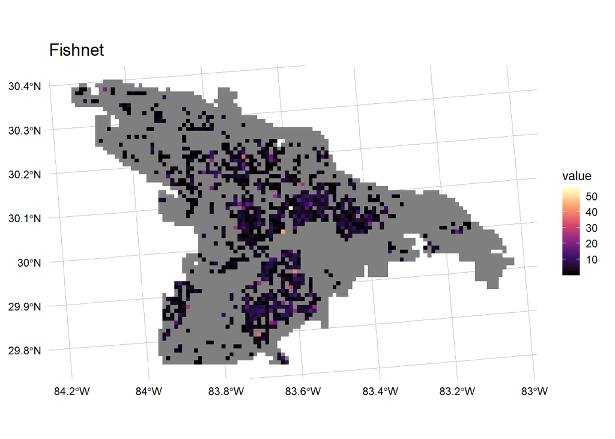

```r
(p2 <- net_littlerock %>%
  ggplot(aes(fill = value)) +
  geom_sf(color = NA) +
  scale_fill_viridis_c(option = "magma") +
  labs(title = "Fishnet")+plotTheme())
```

## Next steps

```r
# group by cell and calc block stats.
net_blocks_intersect <- net_blocks_intersect %>%
  mutate(intersect_area_acres = as.numeric(st_area(net_blocks_intersect)*2.29568e-5)) %>%
  group_by(net_id) %>%
  mutate(cnt = n(),
         pcnt_of_block = intersect_area_acres/acre,
         intersect_pop = value * pcnt_of_block) %>%
  arrange(net_id)

# group by cell and calc block stats.
net_blocks_intersect <- net_blocks_intersect %>%
  mutate(intersect_area_acres = as.numeric(st_area(net_blocks_intersect)*2.29568e-5)) %>%
  group_by(net_id) %>%
  mutate(cnt = n(),
         pcnt_of_block = intersect_area_acres/acre,
         intersect_pop = value * pcnt_of_block) %>%
  arrange(net_id)
```

```r
fishnet_pop <- net_blocks_intersect %>% # xcc
  group_by(net_id) %>%
  summarise(net_pop = sum(intersect_pop)) %>%
  filter(net_pop > 0)   # <-  zeros or no zeros!!!!

######### MAKE NET AND RATE FOR ALL CPS VARS
CPS_vars <- grep("CPS_",names(var_list), value = TRUE)
CPS_agg <- NULL
for(i in seq_along(CPS_vars)){
  var_name <- paste0("net_",CPS_vars[i])
  cat(var_name,"\n")

  CPS_dat <- var_list[[CPS_vars[i]]] %>%
    mutate(value = 1) %>%
    dplyr::select(value)
  fishnet_CPS_var <- aggregate(x = CPS_dat, by = fishnet_pop, FUN = sum) %>%
    st_drop_geometry() %>%
    mutate(Feature = var_name) %>%
    dplyr::select(Feature,value)

  CPS_agg <- rbind(CPS_agg, fishnet_CPS_var)
}
CPS_agg <- CPS_agg %>%
  mutate(id = rep(seq(1:nrow(fishnet_pop)),length(CPS_vars))) %>%
  spread(Feature, value) %>%
  dplyr::select(-id) %>%
  mutate(geometry = fishnet_pop$geometry) %>%
  st_as_sf()
#### Spatial join of fishnet_pop and fishnet_cps to then calculate rate for all CPS features

fishnet_pop_cps <- st_join(fishnet_pop, CPS_agg, join = st_equals) %>%
  mutate_at(vars(paste0("net_",CPS_vars)), funs(rate = ./(net_pop/100)))  %>% # cps per 100 person
  rename_at(vars( contains( "_rate")), funs(paste("rate", gsub("net_|_rate", "", .), sep = "_"))) %>%
  replace(is.na(.), 0) # replace NA with zero

fishnet_coords <- fishnet_pop_cps %>%
  st_centroid() %>%
  st_coordinates() %>%
  as.matrix()
```

```r
fishnet_pop_cps_cut <- fishnet_pop_cps %>%
  mutate(net_CPS_Accepted = ifelse(is.na(net_CPS_Accepted), 0, net_CPS_Accepted)) %>%
  make_cuts(., "net_CPS_Accepted", cuts = "breaks", n_breaks = 10)

CPS_COUNT_BY_FISHNET_PLOT <- ggmap(cps_base_map) +
  geom_sf(data = ll(fishnet_pop_cps_cut), aes(fill = cut_val), inherit.aes = FALSE, color = NA, alpha = 0.8) +
  labs(title = "CPS count per\nfishnet cell") +
  scale_fill_viridis_d(na.value = NA, option = "D", direction = 1, name = "CPS Count") +
  mapTheme() +
  theme(plot.title = element_text(size = 14, family = "sans", face = "plain", hjust = 0),
        plot.subtitle=element_text(size = 11, family = "sans", hjust = 0),
        plot.caption=element_text(size = 10, family = "sans", face = "italic", hjust = 0),
        axis.line = element_blank(),
        legend.title = element_text(size = 10, family = "sans"),
        legend.text = element_text(size = 9, family = "sans"))
```

```r
fishnet_pop_cps_rate_cut <- fishnet_pop_cps %>%
  mutate(rate_CPS_Accepted = ifelse(is.na(rate_CPS_Accepted), 0, rate_CPS_Accepted)) %>%
  make_cuts(., "rate_CPS_Accepted", cuts = "breaks", n_breaks = 10)

CPS_RATE_BY_FISHNET_PLOT <- ggmap(cps_base_map) +
  geom_sf(data = ll(fishnet_pop_cps_rate_cut), aes(fill = cut_val), inherit.aes = FALSE, color = NA, alpha = 0.8) +
  labs(title = "Child Protective Service rate\nper 100 people") +
  scale_fill_viridis_d(na.value = NA, option = "D", direction = 1, name = "CPS Rate\nper 100") +
  mapTheme() +
  theme(plot.title = element_text(size = 14, family = "sans", face = "plain", hjust = 0),
        plot.subtitle=element_text(size = 11, family = "sans", hjust = 0),
        plot.caption=element_text(size = 10, family = "sans", face = "italic", hjust = 0),
        axis.line = element_blank(),
        legend.title = element_text(size = 10, family = "sans"),
        legend.text = element_text(size = 9, family = "sans"))
```